# Machine Learning

Humberto Renteria

2023-11-05

## Humberto Renteria

The goal of your project is to predict the manner in which they did the exercise. This is the “classe” variable in the training set. You may use any of the other variables to predict with. You should create a report describing how you built your model, how you used cross validation, what you think the expected out of sample error is, and why you made the choices you did. You will also use your prediction model to predict 20 different test cases.

Let’s see the dimensions of our data. Train and testing data.

```r
dim(traincsv)
```

```
## [1] 19622   160
```

```r
dim(testcsv)
```

```
## [1]  20 160
```

## Pre Process

We are going to delete those columns that more than 90% of its content is NA and columns with zero variance.

Also we are going to create data partition for validation set. We will be using Cross Validation method in our train control function.

```
## [1] 19622    53
```

## Methods to Use

We will be using Random Forest, Decision Tree and Generalized Boosted Model (GBM).

Let’s process first Random Forest and its prediction.

```r
mod_rf <- train(classe~., data=train, method="rf", trControl = control, tuneLength = 5)

pred_rf <- predict(mod_rf, valid)
cmrf <- confusionMatrix(pred_rf, factor(valid$classe))
cmrf
```

```
## Confusion Matrix and Statistics
##
##           Reference
## Prediction    A    B    C    D    E
##          A 1674    9    0    0    0
##          B    0 1130    5    0    0
##          C    0    0 1018    6    1
##          D    0    0    3  957    4
##          E    0    0    0    1 1077
##
## Overall Statistics
##
##                Accuracy : 0.9951
##                  95% CI : (0.9929, 0.9967)
##     No Information Rate : 0.2845
##     P-Value [Acc > NIR] : < 2.2e-16
##
##                   Kappa : 0.9938
##
##  Mcnemar's Test P-Value : NA
##
## Statistics by Class:
##
##                      Class: A Class: B Class: C Class: D Class: E
## Sensitivity            1.0000   0.9921   0.9922   0.9927   0.9954
## Specificity            0.9979   0.9989   0.9986   0.9986   0.9998
## Pos Pred Value         0.9947   0.9956   0.9932   0.9927   0.9991
## Neg Pred Value         1.0000   0.9981   0.9984   0.9986   0.9990
## Prevalence             0.2845   0.1935   0.1743   0.1638   0.1839
## Detection Rate         0.2845   0.1920   0.1730   0.1626   0.1830
## Detection Prevalence   0.2860   0.1929   0.1742   0.1638   0.1832
## Balanced Accuracy      0.9989   0.9955   0.9954   0.9957   0.9976
```

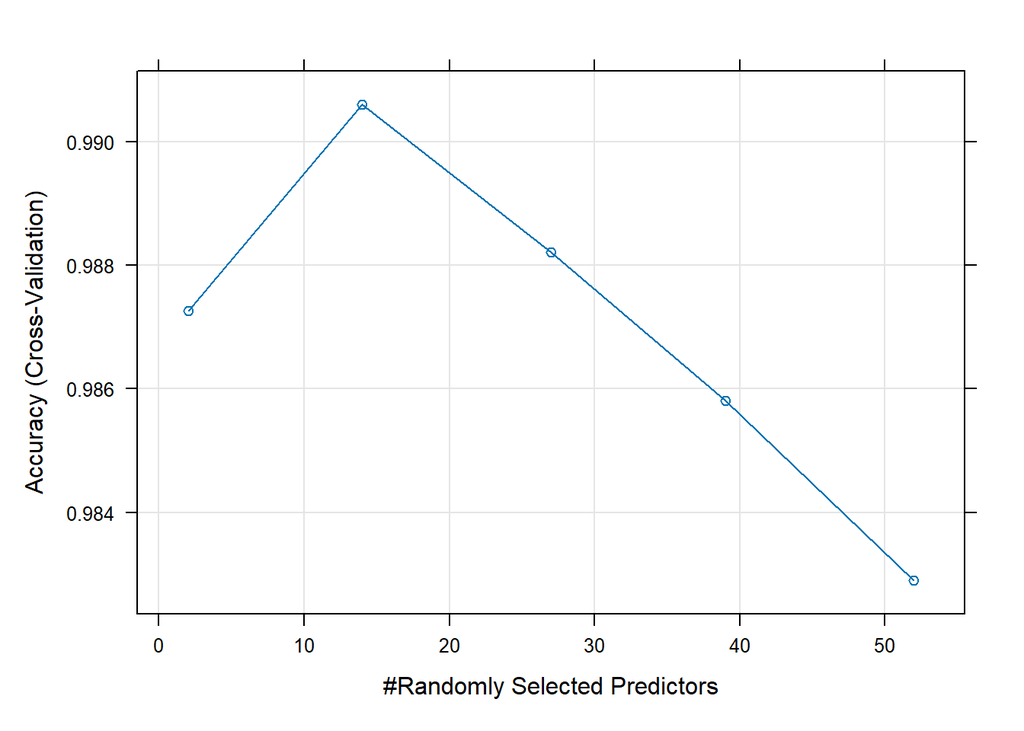

```r
plot(mod_rf)
```

Let’s process Decision trees and its prediction.

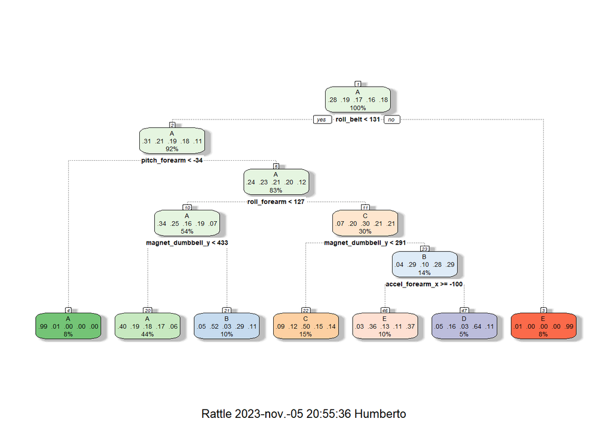

```r
mod_trees <- train(classe~., data=train, method="rpart", trControl = control, tuneLength = 5)
fancyRpartPlot(mod_trees$finalModel)
```

```r
pred_trees <- predict(mod_trees, valid)
cmtrees <- confusionMatrix(pred_trees, factor(valid$classe))
cmtrees
```

```
## Confusion Matrix and Statistics
##
##           Reference
## Prediction    A    B    C    D    E
##          A 1512  458  496  434  159
##          B   34  310   18  186   70
##          C   84  108  427  114  134
##          D   16   38    7  173   33
##          E   28  225   78   57  686
##
## Overall Statistics
##
##                Accuracy : 0.5281
##                  95% CI : (0.5153, 0.5409)
##     No Information Rate : 0.2845
##     P-Value [Acc > NIR] : < 2.2e-16
##
##                   Kappa : 0.3833
##
##  Mcnemar's Test P-Value : < 2.2e-16
##
## Statistics by Class:
##
##                      Class: A Class: B Class: C Class: D Class: E
## Sensitivity            0.9032  0.27217  0.41618  0.17946   0.6340
## Specificity            0.6326  0.93510  0.90945  0.98090   0.9192
## Pos Pred Value         0.4943  0.50162  0.49250  0.64794   0.6387
## Neg Pred Value         0.9427  0.84260  0.88063  0.85920   0.9177
## Prevalence             0.2845  0.19354  0.17434  0.16381   0.1839
## Detection Rate         0.2569  0.05268  0.07256  0.02940   0.1166
## Detection Prevalence   0.5198  0.10501  0.14732  0.04537   0.1825
## Balanced Accuracy      0.7679  0.60364  0.66281  0.58018   0.7766
```

Let’s process Generalize Boosted Models.

```r
mod_gbm <- train(classe~., data=train, method="gbm", trControl = control, tuneLength = 5, verbose = F)

pred_gbm <- predict(mod_gbm, valid)
cmgbm <- confusionMatrix(pred_gbm, factor(valid$classe))
cmgbm
```

```
## Confusion Matrix and Statistics
##
##           Reference
## Prediction    A    B    C    D    E
##          A 1662    9    0    0    2
##          B    8 1125   14    0    2
##          C    3    5 1003    8    2
##          D    0    0    9  952    5
##          E    1    0    0    4 1071
##
## Overall Statistics
##
##                Accuracy : 0.9878
##                  95% CI : (0.9846, 0.9904)
##     No Information Rate : 0.2845
##     P-Value [Acc > NIR] : < 2.2e-16
##
##                   Kappa : 0.9845
##
##  Mcnemar's Test P-Value : NA
##
## Statistics by Class:
##
##                      Class: A Class: B Class: C Class: D Class: E
## Sensitivity            0.9928   0.9877   0.9776   0.9876   0.9898
## Specificity            0.9974   0.9949   0.9963   0.9972   0.9990
## Pos Pred Value         0.9934   0.9791   0.9824   0.9855   0.9954
## Neg Pred Value         0.9972   0.9970   0.9953   0.9976   0.9977
## Prevalence             0.2845   0.1935   0.1743   0.1638   0.1839
## Detection Rate         0.2824   0.1912   0.1704   0.1618   0.1820
## Detection Prevalence   0.2843   0.1952   0.1735   0.1641   0.1828
## Balanced Accuracy      0.9951   0.9913   0.9869   0.9924   0.9944
```

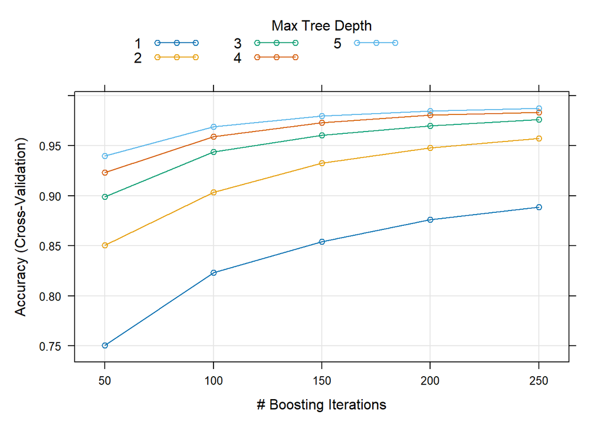

```r
plot(mod_gbm)
```

## Most accurate

The most accurate method was random forest. Let’s make the prediction using that model.

```r
pred <- predict(mod_rf, testcsv)
print(pred)
```

```
##  [1] B A B A A E D B A A B C B A E E A B B B
## Levels: A B C D E
```